# 04 - Model 2

Hannah Harrison

2022-11-17

# Model 1

## Header content

Required libraries:

```r
if (!require("tsne")) install.packages("tsne")
if (!require("knitr")) install.packages("knitr")
if (!require("gridExtra")) install.packages("gridExtra")
if (!require("caret")) install.packages("caret")
if (!require("class")) install.packages("class")
if (!require("dplyr")) install.packages("dplyr")
if (!require("caTools")) install.packages("caTools")
if (!require("lsa")) install.packages("lsa")
if (!require("e1071")) install.packages('e1071')
if (!require("klaR")) install.packages('klaR')
if (!require("xgboost")) install.packages('xgboost')
if (!require("archdata")) install.packages('archdata')
if (!require("fs")) install.packages("fs")

library("fs")
library("tsne")
library("knitr")
library(gridExtra)
library(caret)
library(class)
library(dplyr)
library(caTools)
library(lsa)
library(e1071)
library(klaR)
library("xgboost")
library("archdata")
```

Load the data:

```r
kdd_10_train =read.table(path_wd("..","data","kdd_10_train.tab"),header=TRUE)
```

##Introduction

In this script, I investigate using a Naive Bayes model to predict the class of attack. I then explore the effects of parameter tuning and feature augmentation using techniques such as PCA and scaling on the predictive performance, and select the best model based on this investigation. After this, implement xgboost to investigate whether this will improve on the predictive performance of the Naive Bayes model. At the end of the script, I test the selected model on the competition test data and output the performance metrics.

## Initial exploration

We first take a look at the data, and check that it has been imported correctly.

```r
dim(kdd_10_train)
```

```
## [1] 444618     43
```

```r
head(kdd_10_train)
```

```
##   duration protocol_type service flag src_bytes dst_bytes land wrong_fragment
## 1        0           tcp    http   SF       235      1337    0              0
## 2        0           tcp    http   SF       219      1337    0              0
## 3        0           tcp    http   SF       217      2032    0              0
## 4        0           tcp    http   SF       159      4087    0              0
## 5        0           tcp    http   SF       210       151    0              0
## 6        0           tcp    http   SF       212       786    0              0
##   urgent hot num_failed_logins logged_in num_compromised root_shell
## 1      0   0                 0         1               0          0
## 2      0   0                 0         1               0          0
## 3      0   0                 0         1               0          0
## 4      0   0                 0         1               0          0
## 5      0   0                 0         1               0          0
## 6      0   1                 0         1               0          0
##   su_attempted num_root num_file_creations num_shells num_access_files
```

[output cut: 48 more lines]

We have a total of 444618 observations of 41 predictor variables, and two additional columns containing the attack type and class, or a label of normal if there is no attack. The objective of my model is to predict the attack class from the remaining features.

### Data cleaning

Before any data analysis, it is important to check for and consider imputing any null values.

```r
for (col in kdd_10_train){
  print(is.null(col))
}
```

```
## [1] FALSE
## [1] FALSE
## [1] FALSE
## [1] FALSE
## [1] FALSE
## [1] FALSE
## [1] FALSE
## [1] FALSE
## [1] FALSE
## [1] FALSE
## [1] FALSE
## [1] FALSE
## [1] FALSE
## [1] FALSE
## [1] FALSE
```

[output cut: 28 more lines]

```r
kdd_10_train <- unique(kdd_10_train) #remove duplicate rows

#Which features have 0 variance:
which(apply(kdd_10_train, 2, var) == 0)
```

```
## num_outbound_cmds     is_host_login
##                20                21
```

```r
kdd_10_train <- kdd_10_train[ ,- as.numeric(which(apply(kdd_10_train, 2, var) == 0))] #removing zero variance features

dim(kdd_10_train)
```

```
## [1] 132879     41
```

There are no null values in any column, so we don’t need to consider any imputation here, however we should proceed with caution, as with any network application, a value of 0 for a numeric measurement could indicate that the measurement process failed.

We know that the columns contain the correct data types (factor/ numeric/string), as this was ensured in the data file.

### Initial EDA

```r
table(kdd_10_train$class)
```

```
##
##   DDoS normal  Probe    R2L    UR2
##  50727  79233   1965    903     51
```

```r
prop.table(table(kdd_10_train$class))
```

```
##
##         DDoS       normal        Probe          R2L          UR2
## 0.3817533245 0.5962793218 0.0147878897 0.0067956562 0.0003838078
```

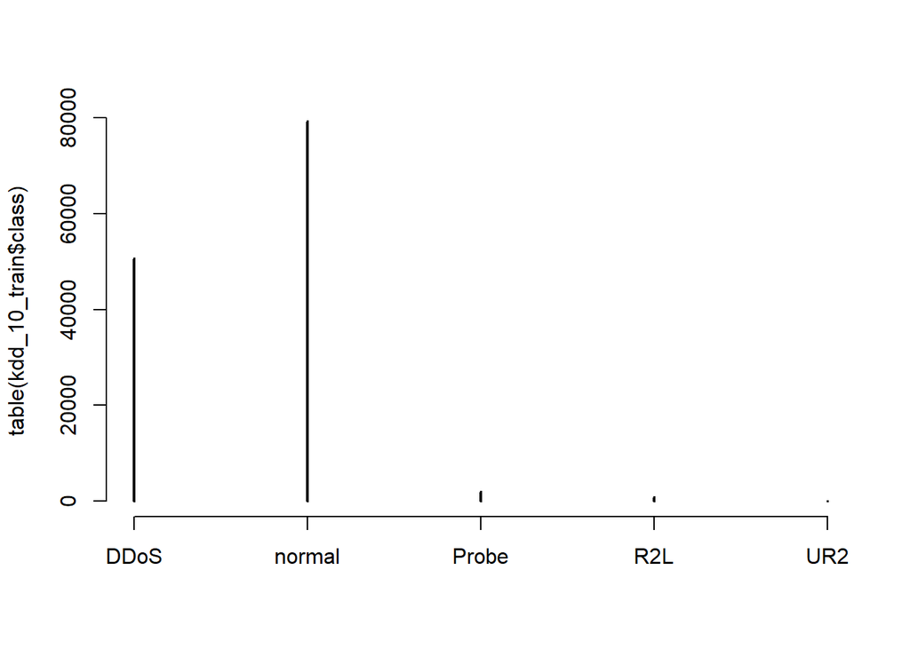

```r
plot(table(kdd_10_train$class))
```

Here we can see that most of the data (almost 60%) is normal network traffic. Of the data which corresponds to an attack, the vast majority are DDoS attacks, followed by Probe, R2L and UR2, which all correspond to relatively few observations. This dataset is highly imbalanced,and so we will need to be aware of this when building a model which needs to classify the points belonging to these different classes accurately.

## Model Fitting

I will further split the training data into two parts so that I can evaluate my models on left out data.

```r
set.seed(123)
kdd_10_train = kdd_10_train[, -40]
split = sample.split(kdd_10_train$class, SplitRatio = 0.75)
train_set = subset(kdd_10_train, split == TRUE)
test_set = subset(kdd_10_train, split == FALSE)
```

## Naive Bayes

I now fit a Naive Bayes model. First, I define the features and labels to input into the model.

```r
train_label = train_set$class
train_features = train_set[ ,1:39]
test_label = test_set$class
test_features = test_set[,1:39]
```

Training the model using the naiveBayes function from the e1071 package.

```r
naive_bayes_model = naiveBayes(as.factor(train_label)~.,
                                    train_features)
```

Performance on the training set:

```r
# Prediction

naive_bayes_pred = predict(naive_bayes_model, train_features)

# Get the accuracy
NB_accuracy <- mean(train_label == naive_bayes_pred,na.rm = TRUE)
NB_accuracy
```

```
## [1] 0.8377568
```

```r
#Confusion matrix
cm <- confusionMatrix(as.factor(naive_bayes_pred),
                       as.factor(train_label))

cm
```

```
## Confusion Matrix and Statistics
##
##           Reference
## Prediction  DDoS normal Probe   R2L   UR2
##     DDoS   36156    809     8     6     1
##     normal   524  45624     1    21     0
##     Probe    912   9252  1462    24     2
##     R2L        8    197     0   213     0
##     UR2      445   3543     3   413    35
##
## Overall Statistics
##
##                Accuracy : 0.8378
##                  95% CI : (0.8355, 0.84)
##     No Information Rate : 0.5963
##     P-Value [Acc > NIR] : < 2.2e-16
##
##                   Kappa : 0.7204
##
##  Mcnemar's Test P-Value : < 2.2e-16
##
## Statistics by Class:
##
##                      Class: DDoS Class: normal Class: Probe Class: R2L
## Sensitivity               0.9503        0.7678      0.99186   0.314623
## Specificity               0.9866        0.9864      0.89622   0.997929
## Pos Pred Value            0.9777        0.9882      0.12547   0.509569
## Neg Pred Value            0.9699        0.7420      0.99986   0.995325
## Prevalence                0.3818        0.5963      0.01479   0.006793
## Detection Rate            0.3628        0.4578      0.01467   0.002137
## Detection Prevalence      0.3711        0.4633      0.11692   0.004194
## Balanced Accuracy         0.9685        0.8771      0.94404   0.656276
##                      Class: UR2
## Sensitivity           0.9210526
## Specificity           0.9557925
## Pos Pred Value        0.0078847
## Neg Pred Value        0.9999685
## Prevalence            0.0003813
## Detection Rate        0.0003512
## Detection Prevalence  0.0445419
## Balanced Accuracy     0.9384225
```

```r
# Stats not so good for R2L; makes sense as this a small class
```

As we can see, the accuracy is 84%, which seems fairly good, however the predictions for R2L are pretty poor. It makes sense that the model would struggle with this class, as we identifies that it appears in relatively few data instances, however in this model, we correctly identify R2L attacks fewer than 1/3 of the time.

Performance on the left out data:

```r
# Prediction

naive_bayes_pred = predict(naive_bayes_model, test_features)

# Get the accuracy
NB_accuracy <- mean(test_label == naive_bayes_pred,na.rm = TRUE)
NB_accuracy
```

```
## [1] 0.8337447
```

```r
cm2 <- confusionMatrix(as.factor(naive_bayes_pred),
                       as.factor(test_label))
cm2
```

```
## Confusion Matrix and Statistics
##
##           Reference
## Prediction  DDoS normal Probe   R2L   UR2
##     DDoS   11994    274     3     2     1
##     normal   195  15139     2    10     1
##     Probe    344   3101   486    11     2
##     R2L        1     80     0    69     0
##     UR2      148   1214     0   134     9
##
## Overall Statistics
##
##                Accuracy : 0.8337
##                  95% CI : (0.8297, 0.8377)
##     No Information Rate : 0.5963
##     P-Value [Acc > NIR] : < 2.2e-16
##
##                   Kappa : 0.7142
##
##  Mcnemar's Test P-Value : < 2.2e-16
##
## Statistics by Class:
##
##                      Class: DDoS Class: normal Class: Probe Class: R2L
## Sensitivity               0.9457        0.7643      0.98982   0.305310
## Specificity               0.9864        0.9845      0.89434   0.997545
## Pos Pred Value            0.9772        0.9864      0.12323   0.460000
## Neg Pred Value            0.9672        0.7388      0.99983   0.995252
## Prevalence                0.3818        0.5963      0.01478   0.006803
## Detection Rate            0.3610        0.4557      0.01463   0.002077
## Detection Prevalence      0.3695        0.4620      0.11872   0.004515
## Balanced Accuracy         0.9661        0.8744      0.94208   0.651427
##                      Class: UR2
## Sensitivity           0.6923077
## Specificity           0.9549493
## Pos Pred Value        0.0059801
## Neg Pred Value        0.9998739
## Prevalence            0.0003913
## Detection Rate        0.0002709
## Detection Prevalence  0.0453040
## Balanced Accuracy     0.8236285
```

The results on the test set are similar, and we see an accuracy of 84% and similar problems with R2L. This is as expected, as the test and training set are from the same distribution, however it does provide a good sanity check that the model isn’t too badly overfitted.

### Cross validation

We can further investigate the models out of sample performance using cross validation, and we can see whether this has the potential to improve the fit. Here I use the caret package, which facilitates the easy implementation of cross validation.

```r
# set up 5-fold cross validation procedure
train_control <- trainControl(
  method = "cv",
  number = 5,
  savePredictions = TRUE
  )

# Train model
nb.m1 <- train(
  x = train_features,
  y = train_label,
  method = "nb",
  trControl = train_control
  )

# Confusion matrix
confusionMatrix(nb.m1)
```

```
## Cross-Validated (5 fold) Confusion Matrix
##
## (entries are percentual average cell counts across resamples)
##
##           Reference
## Prediction DDoS normal Probe  R2L  UR2
##     DDoS   36.4    0.0   0.3  0.0  0.0
##     normal  1.8   59.6   1.0  0.6  0.0
##     Probe   0.0    0.0   0.2  0.0  0.0
##     R2L     0.0    0.0   0.0  0.1  0.0
##     UR2     0.0    0.0   0.0  0.0  0.0
##
##  Accuracy (average) : 0.9627
```

Indeed, cross validation seems to have improved the model accuracy massively, as we have an average accuracy of 96%. How does this model fare on the test set?

```r
pred <- predict(nb.m1, newdata = test_features)
confusionMatrix(as.factor(pred), as.factor(test_label))
```

```
## Confusion Matrix and Statistics
##
##           Reference
## Prediction  DDoS normal Probe   R2L   UR2
##     DDoS   12032      5   108     1     0
##     normal   650  19802   312   225    13
##     Probe      0      0    71     0     0
##     R2L        0      1     0     0     0
##     UR2        0      0     0     0     0
##
## Overall Statistics
##
##                Accuracy : 0.9604
##                  95% CI : (0.9583, 0.9625)
##     No Information Rate : 0.5963
##     P-Value [Acc > NIR] : < 2.2e-16
##
##                   Kappa : 0.9181
##
##  Mcnemar's Test P-Value : NA
##
## Statistics by Class:
##
##                      Class: DDoS Class: normal Class: Probe Class: R2L
## Sensitivity               0.9487        0.9997     0.144603  0.0000000
## Specificity               0.9944        0.9105     1.000000  0.9999697
## Pos Pred Value            0.9906        0.9429     1.000000  0.0000000
## Neg Pred Value            0.9692        0.9995     0.987330  0.9931967
## Prevalence                0.3818        0.5963     0.014780  0.0068031
## Detection Rate            0.3622        0.5961     0.002137  0.0000000
## Detection Prevalence      0.3656        0.6322     0.002137  0.0000301
## Balanced Accuracy         0.9716        0.9551     0.572301  0.4999848
##                      Class: UR2
## Sensitivity           0.0000000
## Specificity           1.0000000
## Pos Pred Value              NaN
## Neg Pred Value        0.9996087
## Prevalence            0.0003913
## Detection Rate        0.0000000
## Detection Prevalence  0.0000000
## Balanced Accuracy     0.5000000
```

```r
summary(pred)
```

```
##   DDoS normal  Probe    R2L    UR2
##  12146  21002     71      1      0
```

Again looking at the average accuracy alone, the model appears to be performing well, however upon closer inspection of the predictions, we see that UR2 is never predicted and R2L is only predicted once, so the model isn’t capturing the smaller classes at all! The model is predicting normal far too much.

### Parameter Tuning

Can the model fit be improved by tuning the hyperparameters? The caret package also offers an easy way to tune parameters. In the naive bayes model, the hyperparameters we can tune are: - the usekernel parameter, which allows us to use a kernel density estimate for continuous variables versus a gaussian density estimate, - adjust, which allows us to adjust the bandwidth of the kernel density (larger numbers mean more flexible density estimate), - fL, which allows us to incorporate the Laplace smoother

Rather than looking at all of these manually, which would take a long time and involve difficult comparisons, I will use the train function to consider the tuning of the parameters and output the best models. I plot the best models so that we can see the parameters which maximise the accuracy.

```r
# This chunk takes a while to run, so I would recommend viewing the knitted file for this part.
# set up tuning grid
search_grid <- expand.grid(
  usekernel = c(TRUE, FALSE),
  fL = 0:3,
  adjust = seq(0, 3, by = 1)
)

# train model
nb.m2 <- train(
  x = train_features,
  y = train_label,
  method = "nb",
  trControl = train_control,#cross validation
  tuneGrid = search_grid #tuning search grid
  )

# top 5 modesl
nb.m2$results %>%
  top_n(5, wt = Accuracy) %>%
  arrange(desc(Accuracy))
```

```
##   usekernel fL adjust  Accuracy     Kappa  AccuracySD     KappaSD
## 1      TRUE  1      1 0.9624118 0.9223325 0.001374090 0.002930407
## 2      TRUE  2      1 0.9623717 0.9222461 0.001407396 0.003001575
## 3      TRUE  3      1 0.9623215 0.9221374 0.001459254 0.003113442
## 4      TRUE  0      1 0.9621208 0.9216919 0.001577954 0.003371766
## 5      TRUE  1      2 0.9607461 0.9187970 0.001521775 0.003258226
```

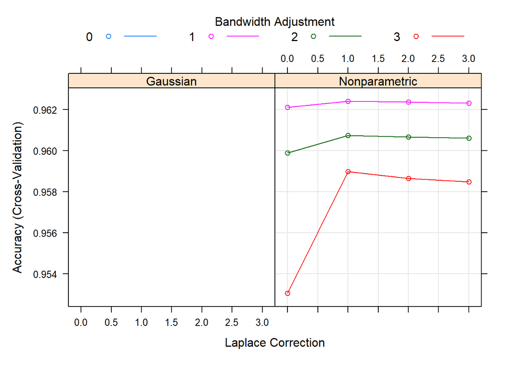

```r
# plot search grid results
plot(nb.m2)
```

Results for best model:

```r
confusionMatrix(nb.m2)
```

```
## Cross-Validated (5 fold) Confusion Matrix
##
## (entries are percentual average cell counts across resamples)
##
##           Reference
## Prediction DDoS normal Probe  R2L  UR2
##     DDoS   36.4    0.0   0.3  0.0  0.0
##     normal  1.8   59.6   1.0  0.6  0.0
##     Probe   0.0    0.0   0.2  0.0  0.0
##     R2L     0.0    0.0   0.0  0.0  0.0
##     UR2     0.0    0.0   0.0  0.0  0.0
##
##  Accuracy (average) : 0.9624
```

And on the left out set:

```r
pred <- predict(nb.m2, newdata = test_features)
confusionMatrix(as.factor(pred), as.factor(test_label))
```

```
## Confusion Matrix and Statistics
##
##           Reference
## Prediction  DDoS normal Probe   R2L   UR2
##     DDoS   12035      5   114     1     0
##     normal   647  19802   305   225    12
##     Probe      0      0    72     0     0
##     R2L        0      1     0     0     0
##     UR2        0      0     0     0     1
##
## Overall Statistics
##
##                Accuracy : 0.9606
##                  95% CI : (0.9584, 0.9626)
##     No Information Rate : 0.5963
##     P-Value [Acc > NIR] : < 2.2e-16
##
##                   Kappa : 0.9184
##
##  Mcnemar's Test P-Value : NA
##
## Statistics by Class:
##
##                      Class: DDoS Class: normal Class: Probe Class: R2L
## Sensitivity               0.9490        0.9997     0.146640  0.0000000
## Specificity               0.9942        0.9113     1.000000  0.9999697
## Pos Pred Value            0.9901        0.9434     1.000000  0.0000000
## Neg Pred Value            0.9693        0.9995     0.987360  0.9931967
## Prevalence                0.3818        0.5963     0.014780  0.0068031
## Detection Rate            0.3623        0.5961     0.002167  0.0000000
## Detection Prevalence      0.3659        0.6319     0.002167  0.0000301
## Balanced Accuracy         0.9716        0.9555     0.573320  0.4999848
##                      Class: UR2
## Sensitivity           0.0769231
## Specificity           1.0000000
## Pos Pred Value        1.0000000
## Neg Pred Value        0.9996388
## Prevalence            0.0003913
## Detection Rate        0.0000301
## Detection Prevalence  0.0000301
## Balanced Accuracy     0.5384615
```

We can see that the top 5 models all have similar accuracy to the previous model, and so tuning in this way doesn’t seem to bring much improvement.

### Feature augmentation

The above code can be edited to also investigate the effects of transforming the features on the best model we have so far. Here I choose to try normalizing with Box Cox, standardizing with center-scaling, and reducing the dimensionality with PCA.

```r
# train model
nb.m3 <- train(
  x = train_features,
  y = train_label,
  method = "nb",
  trControl = train_control, #cross validation
  preProc = c("BoxCox", "center", "scale", "pca") #set transformations
  )

nb.m3$results %>%
  top_n(5, wt = Accuracy) %>%
  arrange(desc(Accuracy))
```

```
##   usekernel fL adjust  Accuracy     Kappa  AccuracySD    KappaSD
## 1      TRUE  0      1 0.9650508 0.9297247 0.004335297 0.00859691
## 2     FALSE  0      1 0.7886981 0.6247056 0.102349194 0.16728366
```

Results for best model:

```r
confusionMatrix(nb.m3)
```

```
## Cross-Validated (5 fold) Confusion Matrix
##
## (entries are percentual average cell counts across resamples)
##
##           Reference
## Prediction DDoS normal Probe  R2L  UR2
##     DDoS   36.0    0.0   0.0  0.0  0.0
##     normal  1.9   58.8   0.4  0.1  0.0
##     Probe   0.3    0.6   1.0  0.0  0.0
##     R2L     0.0    0.1   0.0  0.6  0.0
##     UR2     0.0    0.1   0.0  0.0  0.0
##
##  Accuracy (average) : 0.9651
```

And on the left out set:

```r
pred <- predict(nb.m3, newdata = test_features)
confusionMatrix(as.factor(pred), as.factor(test_label))
```

```
## Confusion Matrix and Statistics
##
##           Reference
## Prediction  DDoS normal Probe   R2L   UR2
##     DDoS   11750      0     0     0     0
##     normal   907  19567   129    23     8
##     Probe     23    164   342     2     1
##     R2L        0     49    20   200     1
##     UR2        2     28     0     1     3
##
## Overall Statistics
##
##                Accuracy : 0.9591
##                  95% CI : (0.9569, 0.9612)
##     No Information Rate : 0.5963
##     P-Value [Acc > NIR] : < 2.2e-16
##
##                   Kappa : 0.9173
##
##  Mcnemar's Test P-Value : NA
##
## Statistics by Class:
##
##                      Class: DDoS Class: normal Class: Probe Class: R2L
## Sensitivity               0.9265        0.9878      0.69654   0.884956
## Specificity               1.0000        0.9204      0.99419   0.997878
## Pos Pred Value            1.0000        0.9483      0.64286   0.740741
## Neg Pred Value            0.9566        0.9809      0.99544   0.999211
## Prevalence                0.3818        0.5963      0.01478   0.006803
## Detection Rate            0.3537        0.5890      0.01030   0.006020
## Detection Prevalence      0.3537        0.6211      0.01601   0.008128
## Balanced Accuracy         0.9633        0.9541      0.84537   0.941417
##                      Class: UR2
## Sensitivity           2.308e-01
## Specificity           9.991e-01
## Pos Pred Value        8.824e-02
## Neg Pred Value        9.997e-01
## Prevalence            3.913e-04
## Detection Rate        9.031e-05
## Detection Prevalence  1.023e-03
## Balanced Accuracy     6.149e-01
```

Whilst the accuracy has decreased slightly here, we can see from the confusion matrix that this model is much better at detecting R2L attacks. Hence, scaling has improved the detection rate for R2L at only a small cost to the accuracy. UR2 also at least now has some predictions, however as such a tiny class, it is still proving difficult to identify.

In summary, the fit of Naive Bayes models to this data can be improved by cross validation and scaling, and we can achieve a high model accuracy. Naive Bayes models struggle to identify the smaller classes, however this is improved by feature augmentation.

## Tree Based methods

I will now investigate a tree based method to see if this can improve on the prediction of small classes.

### Xgboost

I now implement a boosted decision tree using xgboost.

The XGBoost algorithm requires the class labels to start at 0 and increase sequentially to the maximum number of classes. This is a bit of an inconvenience as you need to keep track of whick attack class goes with which label. Also, we need to be careful when adding or removing a 1 to go from the zero based labels to the 1 based labels. We have 1 = DDoS 2 = Normal 3 = Probe 4 = R2L 5 = UR2

I also use label encoding for the categorical variables rather than one-hot, following reading their comparison in reference 1.

```r
train <- train_set

for (i in c(2,3,4, 40)){
  train[,i] = as.numeric(as.factor(train[,i]))
}

table(train_set$class)
```

```
##
##   DDoS normal  Probe    R2L    UR2
##  38045  59425   1474    677     38
```

```r
table(train$class)
```

```
##
##     1     2     3     4     5
## 38045 59425  1474   677    38
```

```r
train$class = train$class - 1
summary(train)
```

```
##     duration     protocol_type      service           flag
##  Min.   :    0   Min.   :1.000   Min.   : 1.00   Min.   : 1.000
##  1st Qu.:    0   1st Qu.:2.000   1st Qu.:20.00   1st Qu.: 6.000
##  Median :    0   Median :2.000   Median :20.00   Median :10.000
##  Mean   :  130   Mean   :2.066   Mean   :30.84   Mean   : 7.949
##  3rd Qu.:    0   3rd Qu.:2.000   3rd Qu.:44.00   3rd Qu.:10.000
##  Max.   :58329   Max.   :3.000   Max.   :66.00   Max.   :11.000
##    src_bytes           dst_bytes            land           wrong_fragment
##  Min.   :        0   Min.   :      0   Min.   :0.0000000   Min.   :0.00000
##  1st Qu.:        0   1st Qu.:      0   1st Qu.:0.0000000   1st Qu.:0.00000
##  Median :      147   Median :    105   Median :0.0000000   Median :0.00000
##  Mean   :    10177   Mean   :   2726   Mean   :0.0001405   Mean   :0.01948
##  3rd Qu.:      286   3rd Qu.:   1111   3rd Qu.:0.0000000   3rd Qu.:0.00000
##  Max.   :693375640   Max.   :5155468   Max.   :1.0000000   Max.   :3.00000
##      urgent              hot           num_failed_logins    logged_in
##  Min.   :0.00e+00   Min.   : 0.00000   Min.   :0.000000   Min.   :0.0000
##  1st Qu.:0.00e+00   1st Qu.: 0.00000   1st Qu.:0.000000   1st Qu.:0.0000
##  Median :0.00e+00   Median : 0.00000   Median :0.000000   Median :0.0000
##  Mean   :6.02e-05   Mean   : 0.09738   Mean   :0.000552   Mean   :0.4849
##  3rd Qu.:0.00e+00   3rd Qu.: 0.00000   3rd Qu.:0.000000   3rd Qu.:1.0000
##  Max.   :3.00e+00   Max.   :30.00000   Max.   :5.000000   Max.   :1.0000
##  num_compromised      root_shell         su_attempted          num_root
##  Min.   :  0.0000   Min.   :0.0000000   Min.   :0.0000000   Min.   :  0.0000
##  1st Qu.:  0.0000   1st Qu.:0.0000000   1st Qu.:0.0000000   1st Qu.:  0.0000
##  Median :  0.0000   Median :0.0000000   Median :0.0000000   Median :  0.0000
##  Mean   :  0.0231   Mean   :0.0004214   Mean   :0.0001304   Mean   :  0.0341
##  3rd Qu.:  0.0000   3rd Qu.:0.0000000   3rd Qu.:0.0000000   3rd Qu.:  0.0000
##  Max.   :767.0000   Max.   :1.0000000   Max.   :2.0000000   Max.   :857.0000
##  num_file_creations    num_shells        num_access_files   is_guest_login
##  Min.   : 0.000000   Min.   :0.0000000   Min.   :0.000000   Min.   :0.000000
##  1st Qu.: 0.000000   1st Qu.:0.0000000   1st Qu.:0.000000   1st Qu.:0.000000
##  Median : 0.000000   Median :0.0000000   Median :0.000000   Median :0.000000
##  Mean   : 0.003974   Mean   :0.0003813   Mean   :0.003542   Mean   :0.004546
##  3rd Qu.: 0.000000   3rd Qu.:0.0000000   3rd Qu.:0.000000   3rd Qu.:0.000000
##  Max.   :28.000000   Max.   :2.0000000   Max.   :6.000000   Max.   :1.000000
##      count          srv_count       serror_rate     srv_serror_rate
##  Min.   :  0.00   Min.   :  0.00   Min.   :0.0000   Min.   :0.0000
##  1st Qu.:  2.00   1st Qu.:  2.00   1st Qu.:0.0000   1st Qu.:0.0000
##  Median : 13.00   Median :  8.00   Median :0.0000   Median :0.0000
##  Mean   : 75.75   Mean   : 12.96   Mean   :0.2967   Mean   :0.2969
```

[output cut: 22 more lines]

```
##  Max.   :1.00000        Max.   :1.00000             Max.   :1.00000
##  dst_host_serror_rate dst_host_srv_serror_rate dst_host_rerror_rate
##  Min.   :0.000        Min.   :0.0000           Min.   :0.0000
##  1st Qu.:0.000        1st Qu.:0.0000           1st Qu.:0.0000
##  Median :0.000        Median :0.0000           Median :0.0000
##  Mean   :0.297        Mean   :0.2963           Mean   :0.1124
##  3rd Qu.:1.000        3rd Qu.:1.0000           3rd Qu.:0.0000
##  Max.   :1.000        Max.   :1.0000           Max.   :1.0000
##  dst_host_srv_rerror_rate     class
##  Min.   :0.0000           Min.   :0.0000
##  1st Qu.:0.0000           1st Qu.:0.0000
##  Median :0.0000           Median :1.0000
##  Mean   :0.1096           Mean   :0.6478
##  3rd Qu.:0.0000           3rd Qu.:1.0000
##  Max.   :1.0000           Max.   :4.0000
```

```r
#making xgboost matrix

data_label <- train[,"class"]
data_matrix <- xgb.DMatrix(data = as.matrix(train), label = data_label)
```

### Parameters and cross validation

Here I set the fitting parameters and then fit a series of XGBoost models to each cv.nfold. The list of xgb_params holds the objective, which I set to multi:softprob and the eval_metric, which I set to to mlogloss. These two parameters tell the XGBoost algorithm that we want to use probabilistic classification and use a multiclass logloss as the evaluation metric. Use of the multi:softprob objective also requires the input of the number of classes.

The other parameters of note are nrounds and prediction. The nrounds parameter is the number of iterations and the prediction argument tells XGBoost to save the out-of-fold predictions so that we can use them to assess generalization error.

```r
#CV
numberOfClasses <- length(unique(train$class))
xgb_params <- list("objective" = "multi:softprob",
                   "eval_metric" = "mlogloss",
                   "num_class" = numberOfClasses)
nround    <- 50 # number of XGBoost rounds
cv.nfold  <- 5
```

```r
# Fit XGB models and save the out of fold predictions
cv_model <- xgb.cv(params = xgb_params,
                   data = data_matrix,
                   nrounds = nround,
                   nfold = cv.nfold,
                   verbose = FALSE,
                   prediction = TRUE)
```

To assess prediction error, we use the data returned from the pred slot of the cv_model, which contains the predicted value for each observation in our train dataset when it was in the kth fold (the out-of-fold sample). This sample was not used to train the model so therefore acts as an independent sample for testing. This step allows us to derived an error estimate on all of our train samples as if the were independent from the model fit.

The pred object returned from xgb.cv() contains a column for each of the classes and the probability that each observation belongs to each class. This why I chose the multi:softprob objective function as opposed to the multi:softmax function that predicts the model likely class. However, since we want to test the prediction, we do need to assign a class, so we use max.col() to assign the class that has the highest probability.

```r
# Prediction
prediction <- data.frame(cv_model$pred) %>%
  mutate(max_prob = max.col(., ties.method = "last"),
         label = data_label + 1)
head(prediction)
```

```
##             X1        X2           X3           X4           X5 max_prob label
## 1 8.402820e-06 0.9999770 5.029387e-06 4.029569e-06 5.578226e-06        2     2
## 2 7.700082e-06 0.9999782 4.591191e-06 3.755055e-06 5.822391e-06        2     2
## 3 5.712566e-06 0.9999841 3.432851e-06 2.730681e-06 3.937622e-06        2     2
## 4 5.338393e-06 0.9999858 3.141214e-06 2.570917e-06 3.163225e-06        2     2
## 5 5.509289e-06 0.9999852 3.297508e-06 2.641979e-06 3.363491e-06        2     2
## 6 4.899097e-06 0.9999864 2.944010e-06 2.341830e-06 3.376905e-06        2     2
```

```r
confusionMatrix(factor(prediction$max_prob),
                factor(prediction$label),
                mode = "everything")
```

```
## Confusion Matrix and Statistics
##
##           Reference
## Prediction     1     2     3     4     5
##          1 38045     0     0     0     0
##          2     0 59425     0     0     0
##          3     0     0  1474     0     0
##          4     0     0     0   677     0
##          5     0     0     0     0    38
##
## Overall Statistics
##
##                Accuracy : 1
##                  95% CI : (1, 1)
##     No Information Rate : 0.5963
##     P-Value [Acc > NIR] : < 2.2e-16
##
##                   Kappa : 1
##
##  Mcnemar's Test P-Value : NA
##
## Statistics by Class:
##
##                      Class: 1 Class: 2 Class: 3 Class: 4  Class: 5
## Sensitivity            1.0000   1.0000  1.00000 1.000000 1.0000000
## Specificity            1.0000   1.0000  1.00000 1.000000 1.0000000
## Pos Pred Value         1.0000   1.0000  1.00000 1.000000 1.0000000
## Neg Pred Value         1.0000   1.0000  1.00000 1.000000 1.0000000
## Precision              1.0000   1.0000  1.00000 1.000000 1.0000000
## Recall                 1.0000   1.0000  1.00000 1.000000 1.0000000
## F1                     1.0000   1.0000  1.00000 1.000000 1.0000000
## Prevalence             0.3818   0.5963  0.01479 0.006793 0.0003813
## Detection Rate         0.3818   0.5963  0.01479 0.006793 0.0003813
## Detection Prevalence   0.3818   0.5963  0.01479 0.006793 0.0003813
## Balanced Accuracy      1.0000   1.0000  1.00000 1.000000 1.0000000
```

We see that this appears to work extremely well, in fact it classifies every data instance correctly. I now fit the model based on all of the data.

Train full model:

```r
best_model <- xgb.train(params = xgb_params,
                       data = data_matrix,
                       nrounds = nround)
```

Testing on left out set:

```r
#Formatting
test <- test_set

for (i in c(2,3,4, 40)){
  test[,i] = as.numeric(as.factor(test[,i]))
}
test$class = test$class - 1
summary(test)
```

```
##     duration       protocol_type     service           flag
##  Min.   :    0.0   Min.   :1.00   Min.   : 1.00   Min.   : 1.000
##  1st Qu.:    0.0   1st Qu.:2.00   1st Qu.:20.00   1st Qu.: 6.000
##  Median :    0.0   Median :2.00   Median :20.00   Median :10.000
##  Mean   :  140.3   Mean   :2.07   Mean   :30.28   Mean   : 7.967
##  3rd Qu.:    0.0   3rd Qu.:2.00   3rd Qu.:43.00   3rd Qu.:10.000
##  Max.   :42088.0   Max.   :3.00   Max.   :63.00   Max.   :11.000
##    src_bytes         dst_bytes            land           wrong_fragment
##  Min.   :      0   Min.   :      0   Min.   :0.0000000   Min.   :0.00000
##  1st Qu.:      0   1st Qu.:      0   1st Qu.:0.0000000   1st Qu.:0.00000
##  Median :    147   Median :    105   Median :0.0000000   Median :0.00000
##  Mean   :   2852   Mean   :   3126   Mean   :0.0001204   Mean   :0.02134
##  3rd Qu.:    287   3rd Qu.:   1137   3rd Qu.:0.0000000   3rd Qu.:0.00000
##  Max.   :5135678   Max.   :5153771   Max.   :1.0000000   Max.   :3.00000
##      urgent       hot          num_failed_logins     logged_in
##  Min.   :0   Min.   : 0.0000   Min.   :0.0000000   Min.   :0.0000
##  1st Qu.:0   1st Qu.: 0.0000   1st Qu.:0.0000000   1st Qu.:0.0000
##  Median :0   Median : 0.0000   Median :0.0000000   Median :0.0000
##  Mean   :0   Mean   : 0.1067   Mean   :0.0003913   Mean   :0.4843
##  3rd Qu.:0   3rd Qu.: 0.0000   3rd Qu.:0.0000000   3rd Qu.:1.0000
##  Max.   :0   Max.   :30.0000   Max.   :1.0000000   Max.   :1.0000
##  num_compromised      root_shell         su_attempted          num_root
##  Min.   :  0.0000   Min.   :0.0000000   Min.   :0.0000000   Min.   :  0.0000
##  1st Qu.:  0.0000   1st Qu.:0.0000000   1st Qu.:0.0000000   1st Qu.:  0.0000
##  Median :  0.0000   Median :0.0000000   Median :0.0000000   Median :  0.0000
##  Mean   :  0.0422   Mean   :0.0002709   Mean   :0.0001505   Mean   :  0.0585
##  3rd Qu.:  0.0000   3rd Qu.:0.0000000   3rd Qu.:0.0000000   3rd Qu.:  0.0000
##  Max.   :884.0000   Max.   :1.0000000   Max.   :2.0000000   Max.   :993.0000
##  num_file_creations   num_shells        num_access_files  is_guest_login
##  Min.   :0.000000   Min.   :0.0000000   Min.   :0.00000   Min.   :0.000000
##  1st Qu.:0.000000   1st Qu.:0.0000000   1st Qu.:0.00000   1st Qu.:0.000000
##  Median :0.000000   Median :0.0000000   Median :0.00000   Median :0.000000
##  Mean   :0.002709   Mean   :0.0004214   Mean   :0.00301   Mean   :0.004967
##  3rd Qu.:0.000000   3rd Qu.:0.0000000   3rd Qu.:0.00000   3rd Qu.:0.000000
##  Max.   :9.000000   Max.   :2.0000000   Max.   :8.00000   Max.   :1.000000
##      count          srv_count       serror_rate     srv_serror_rate
##  Min.   :  1.00   Min.   :  1.00   Min.   :0.0000   Min.   :0.0000
##  1st Qu.:  2.00   1st Qu.:  2.00   1st Qu.:0.0000   1st Qu.:0.0000
##  Median : 13.00   Median :  8.00   Median :0.0000   Median :0.0000
##  Mean   : 75.67   Mean   : 13.18   Mean   :0.2972   Mean   :0.2973
```

[output cut: 22 more lines]

```
##  Max.   :1.00000        Max.   :1.00000             Max.   :1.00000
##  dst_host_serror_rate dst_host_srv_serror_rate dst_host_rerror_rate
##  Min.   :0.0000       Min.   :0.0000           Min.   :0.0000
##  1st Qu.:0.0000       1st Qu.:0.0000           1st Qu.:0.0000
##  Median :0.0000       Median :0.0000           Median :0.0000
##  Mean   :0.2973       Mean   :0.2967           Mean   :0.1097
##  3rd Qu.:1.0000       3rd Qu.:1.0000           3rd Qu.:0.0000
##  Max.   :1.0000       Max.   :1.0000           Max.   :1.0000
##  dst_host_srv_rerror_rate     class
##  Min.   :0.000            Min.   :0.0000
##  1st Qu.:0.000            1st Qu.:0.0000
##  Median :0.000            Median :1.0000
##  Mean   :0.107            Mean   :0.6478
##  3rd Qu.:0.000            3rd Qu.:1.0000
##  Max.   :1.000            Max.   :4.0000
```

```r
#making xgboost matrix

label <- test[,"class"]
test_matrix <- xgb.DMatrix(data = as.matrix(test), label = label)

#Prediction
pred <- predict(best_model, test_matrix)
test_prediction <- matrix(pred, nrow = numberOfClasses,
                          ncol=length(pred)/numberOfClasses) %>%
  t() %>%
  data.frame() %>%
  mutate(label = label + 1,
         max_prob = max.col(., "last"))
# confusion matrix of test set
confusionMatrix(factor(test_prediction$max_prob),
                factor(test_prediction$label),
                mode = "everything")
```

```
## Confusion Matrix and Statistics
##
##           Reference
## Prediction     1     2     3     4     5
##          1 12682     0     0     0     0
##          2     0 19808     0     0     0
##          3     0     0   491     0     0
##          4     0     0     0   226     0
##          5     0     0     0     0    13
##
## Overall Statistics
##
##                Accuracy : 1
##                  95% CI : (0.9999, 1)
##     No Information Rate : 0.5963
##     P-Value [Acc > NIR] : < 2.2e-16
##
##                   Kappa : 1
##
##  Mcnemar's Test P-Value : NA
##
## Statistics by Class:
##
##                      Class: 1 Class: 2 Class: 3 Class: 4  Class: 5
## Sensitivity            1.0000   1.0000  1.00000 1.000000 1.0000000
## Specificity            1.0000   1.0000  1.00000 1.000000 1.0000000
## Pos Pred Value         1.0000   1.0000  1.00000 1.000000 1.0000000
## Neg Pred Value         1.0000   1.0000  1.00000 1.000000 1.0000000
## Precision              1.0000   1.0000  1.00000 1.000000 1.0000000
## Recall                 1.0000   1.0000  1.00000 1.000000 1.0000000
## F1                     1.0000   1.0000  1.00000 1.000000 1.0000000
## Prevalence             0.3818   0.5963  0.01478 0.006803 0.0003913
## Detection Rate         0.3818   0.5963  0.01478 0.006803 0.0003913
## Detection Prevalence   0.3818   0.5963  0.01478 0.006803 0.0003913
## Balanced Accuracy      1.0000   1.0000  1.00000 1.000000 1.0000000
```

We get an accuracy of 100%, even on the left out data and even for the small classes. Predicting using this model is also much faster than with the naive bayes model and so it seems like a win-win! Hence this is the model I will use for performance evaluation on the testing data. It will be interesting to see how it reacts to the unseen attack types in the labelled test data, as decision trees have a tendency to overfit the data.

# Competition Testing

Here I run the model on the competition test data and output the performance metrics which will be evaluated in 07 - Performance and Discussion.

Load the test data:

```r
kdd_10_test =read.table(path_wd("..","data","kdd_10_test.tab"),header=TRUE)
labeled_test =read.table(path_wd("..","data","labeled_test.tab"),header=TRUE)
table(kdd_10_test$class)
```

```
##
##   DDoS normal  Probe    R2L    UR2
##  39102   9763    423    111      3
```

```r
table(labeled_test$class)
```

```
##
##   DDoS normal  Probe    R2L    UR2
## 229853  60592   4166  13781   2636
```

Preparing the data:

```r
kdd_10_test <- kdd_10_test[,-c(20,21,42)] #removing the same columns as in training
labeled_test<- labeled_test[,-c(20,21,42)]

for (i in c(2,3,4, 40)){
  kdd_10_test[,i] = as.numeric(as.factor(kdd_10_test[,i]))
}
kdd_10_test$class = kdd_10_test$class - 1
label_1 = kdd_10_test$class

for (i in c(2,3,4, 40)){
  labeled_test[,i] = as.numeric(as.factor(labeled_test[,i]))
}
labeled_test$class = labeled_test$class - 1
label_2 = labeled_test$class


#making xgboost matrices

labeled_test_matrix <- xgb.DMatrix(data = as.matrix(labeled_test), label = label_2)
kdd_10_test_matrix <- xgb.DMatrix(data = as.matrix(kdd_10_test), label = label_1)
```

Prediction for kdd_10_test:

```r
pred <- predict(best_model, kdd_10_test_matrix)
test_prediction <- matrix(pred, nrow = numberOfClasses,
                          ncol=length(pred)/numberOfClasses) %>%
  t() %>%
  data.frame() %>%
  mutate(label_1 = label_1 + 1,
         max_prob = max.col(., "last"))
# confusion matrix of test set
confusionMatrix(factor(test_prediction$max_prob),
                factor(test_prediction$label),
                mode = "everything")
```

```
## Confusion Matrix and Statistics
##
##           Reference
## Prediction     1     2     3     4     5
##          1 39102     0     0     0     0
##          2     0  9763     0     0     0
##          3     0     0   423     0     0
##          4     0     0     0   111     0
##          5     0     0     0     0     3
##
## Overall Statistics
##
##                Accuracy : 1
##                  95% CI : (0.9999, 1)
##     No Information Rate : 0.7915
##     P-Value [Acc > NIR] : < 2.2e-16
##
##                   Kappa : 1
##
##  Mcnemar's Test P-Value : NA
##
## Statistics by Class:
##
##                      Class: 1 Class: 2 Class: 3 Class: 4  Class: 5
## Sensitivity            1.0000   1.0000 1.000000 1.000000 1.000e+00
## Specificity            1.0000   1.0000 1.000000 1.000000 1.000e+00
## Pos Pred Value         1.0000   1.0000 1.000000 1.000000 1.000e+00
## Neg Pred Value         1.0000   1.0000 1.000000 1.000000 1.000e+00
## Precision              1.0000   1.0000 1.000000 1.000000 1.000e+00
## Recall                 1.0000   1.0000 1.000000 1.000000 1.000e+00
## F1                     1.0000   1.0000 1.000000 1.000000 1.000e+00
## Prevalence             0.7915   0.1976 0.008562 0.002247 6.073e-05
## Detection Rate         0.7915   0.1976 0.008562 0.002247 6.073e-05
## Detection Prevalence   0.7915   0.1976 0.008562 0.002247 6.073e-05
## Balanced Accuracy      1.0000   1.0000 1.000000 1.000000 1.000e+00
```

Prediction for labeled_test:

```r
pred <- predict(best_model, labeled_test_matrix)
test_prediction <- matrix(pred, nrow = numberOfClasses,
                          ncol=length(pred)/numberOfClasses) %>%
  t() %>%
  data.frame() %>%
  mutate(label_2 = label_2 + 1,
         max_prob = max.col(., "last"))
# confusion matrix of test set
confusionMatrix(factor(test_prediction$max_prob),
                factor(test_prediction$label),
                mode = "everything")
```

```
## Confusion Matrix and Statistics
##
##           Reference
## Prediction      1      2      3      4      5
##          1 229853      0      0      0      0
##          2      0  60592      0      0      0
##          3      0      0   4166      0      0
##          4      0      0      0  13781      0
##          5      0      0      0      0   2636
##
## Overall Statistics
##
##                Accuracy : 1
##                  95% CI : (1, 1)
##     No Information Rate : 0.739
##     P-Value [Acc > NIR] : < 2.2e-16
##
##                   Kappa : 1
##
##  Mcnemar's Test P-Value : NA
##
## Statistics by Class:
##
##                      Class: 1 Class: 2 Class: 3 Class: 4 Class: 5
## Sensitivity             1.000   1.0000  1.00000  1.00000 1.000000
## Specificity             1.000   1.0000  1.00000  1.00000 1.000000
## Pos Pred Value          1.000   1.0000  1.00000  1.00000 1.000000
## Neg Pred Value          1.000   1.0000  1.00000  1.00000 1.000000
## Precision               1.000   1.0000  1.00000  1.00000 1.000000
## Recall                  1.000   1.0000  1.00000  1.00000 1.000000
## F1                      1.000   1.0000  1.00000  1.00000 1.000000
## Prevalence              0.739   0.1948  0.01339  0.04431 0.008475
## Detection Rate          0.739   0.1948  0.01339  0.04431 0.008475
## Detection Prevalence    0.739   0.1948  0.01339  0.04431 0.008475
## Balanced Accuracy       1.000   1.0000  1.00000  1.00000 1.000000
```

## References

1. One hot vs label encoding: https://www.ijeat.org/wp-content/uploads/papers/v11i2/B32381211221.pdf
2. Ideas for classification of KDD cup data: https://medium.com/analytics-vidhya/building-an-intrusion-detection-model-using-kdd-cup99-dataset-fb4cba4189ed
3. Naive Bayes and how to use gridsearch: https://uc-r.github.io/naive_bayes
4. XGBoost for multi-class problems : https://rpubs.com/mharris/multiclass_xgboost